# Sistema de Ranqueamento para Equipes de Futebol Sul-Americanos

### Manipulação dos dados.

Após a raspagem e união de todos os 28 campeonatos e temporadas em uma única planilha, a seguinte base foi obtida:

|  | X | Data | Mandante | Placar | Visitante | Campeonato |
| --- | --- | --- | --- | --- | --- | --- |
| 1 | 1 | 27/07/2019 | Racing Club | 0:0 (0:0) | Unión de Santa Fe | Argentina Serie A |
| 2 | 2 |  | Colón de Santa Fe | 0:1 (0:1) | Patronato de Paraná | Argentina Serie A |
| 3 | 3 |  | San Lorenzo | 3:2 (1:0) | Godoy Cruz | Argentina Serie A |
| 4 | 4 |  | Lanús | 1:1 (1:0) | Gimnasia de La Plata | Argentina Serie A |
| 5 | 5 | 28/07/2019 | Argentinos Juniors | 1:1 (1:0) | River Plate | Argentina Serie A |

Foi necessário completar as datas dos jogos, uma vez que são importantes para o modelo. Os placares são da classe string e informados de várias formas diferentes (alguns erros foram encontrados nos placares). O código abaixo realiza todo o tratamento da base de dados e separa em data frames que facilitam o trabalho. Os principais data frames são:

- df.times
- jogos
- nacao

#### Estas funções organizam a base e retornam data.frames.

```r
###Limpando os dados e completando datas faltantes
limpar_dados = function(jogos){
  jogos = mutate(jogos,id = 1:nrow(jogos))
  x = jogos[str_detect(jogos$Mandante,'.Round'),] %>% subset(id) %>% unlist()
  jogos =jogos[-x,]
  ####################################################################################
  jogos = completar_data(jogos)
  #####################################################################################
  jogos$Data=str_remove_all(jogos$Data,"[/:]")
  jogos$Data = as.numeric(jogos$Data)
  jogos$Data=dmy(jogos$Data)
  jogos$Placar[jogos$Placar=="-:-"] = NA
  jogos = na.omit(jogos)

  return(jogos)
}

completar_data = function(games){
  for (i in 1:length(games$Data)){
    if (games$Data[i]==""){
      games$Data[i]=games$Data[i-1]


    }
  }
  return(games)
}

jogos = limpar_dados(jogos)

jogos$X = NULL
jogos$Mandante = as.character(jogos$Mandante)
jogos$Placar = as.character(jogos$Placar)
jogos$Visitante = as.character(jogos$Visitante)
jogos$Campeonato = as.character(jogos$Campeonato)
jogos = mutate(jogos, Placar = str_replace_all(Placar,' ',''))

######Correção dos placares#######################
palavras = c('dnp','dec','annul','pso','aet','WO','abor.','resch.')
linhas = to_list(for(i in 1:nrow(jogos)) for(j in palavras) if(str_detect(jogos$Placar[i],j)) jogos[i,]) %>%
  join_all(type = 'full')
jogos = anti_join(jogos,linhas, by ='id')
jogos = mutate(jogos, tamanho = str_length(jogos$Placar))
jogos = subset(jogos, tamanho==3 | tamanho==8)
jogos = mutate(jogos, GH = as.numeric(str_sub(jogos$Placar,1,1)), GA = as.numeric(str_sub(jogos$Placar,3,3)))
jogos$tamanho = NULL
jogos$Placar = NULL
jogos = arrange(jogos,Data)



######Criando dataframes por paises################
df_Brazil = jogos[str_detect(jogos$Campeonato,'Brazil'),] %>% mutate(pais = 'Brazil')
df_Argentina = jogos[str_detect(jogos$Campeonato,'Argentina'),] %>% mutate(pais = 'Argentina')
df_Chile = jogos[str_detect(jogos$Campeonato,'Chile'),] %>% mutate(pais = 'Chile')
df_Bolivia = jogos[str_detect(jogos$Campeonato,'Bolivia'),] %>% mutate(pais = 'Bolivia')
df_Colombia = jogos[str_detect(jogos$Campeonato,'Colombia'),] %>% mutate(pais = 'Colombia')
df_Ecuador = jogos[str_detect(jogos$Campeonato,'Ecuador'),] %>% mutate(pais = 'Ecuador')
df_Paraguay = jogos[str_detect(jogos$Campeonato,'Paraguay'),] %>% mutate(pais = 'Paraguay')
df_Peru = jogos[str_detect(jogos$Campeonato,'Peru'),] %>% mutate(pais = 'Peru')
df_Uruguay = jogos[str_detect(jogos$Campeonato,'Uruguay'),] %>% mutate(pais = 'Uruguay')
df_Venezuela = jogos[str_detect(jogos$Campeonato,'Venezuela'),] %>% mutate(pais = 'Venezuela')
df_Sulamericana = jogos[str_detect(jogos$Campeonato,'Copa Sudamericana'),] %>% mutate(pais = 'Sudamericana')
df_Libertadores = jogos[str_detect(jogos$Campeonato,'Copa Libertadores'),] %>% mutate(pais = 'Libertadores')

df = list(df_Brazil,df_Argentina,df_Chile,df_Bolivia,df_Colombia,
             df_Ecuador,df_Paraguay,df_Peru,df_Uruguay,df_Venezuela,
             df_Sulamericana,df_Libertadores)

times_paises = function(df){
  x =  as.vector(df$Mandante) %>% unique()
  y = as.vector(df$Visitante) %>% unique()
  z = as.vector(df$pais) %>% unique()
  xy = c(x,y) %>% unique()
  xy = data.frame(nome = xy,pais=z)

  return(xy)
}

df.times = lapply(1:10,function(i) times_paises(df[[i]])) %>% join_all(type = 'full')
inter = times_paises(df_Libertadores)
inter = anti_join(inter,df.times,by='nome')
inter$pais = 'Convidado'
x = data.frame(nome = c('Brazil','Argentina','Chile','Bolivia','Colombia','Ecuador','Paraguay','Peru','Uruguay','Venezuela','Convidado'),
               pais = c('Brazil','Argentina','Chile','Bolivia','Colombia','Ecuador','Paraguay','Peru','Uruguay','Venezuela','Convidado'))
df.times = rbind(df.times,inter) %>% rbind(x)
nacao = inner_join(df_Libertadores,df.times,by=c('Mandante'='nome'))
nacao = inner_join(nacao,df.times,by=c('Visitante'='nome')) %>% arrange(Data)
nacao = select(nacao,Data,pais.y,pais,Campeonato,id,GH,GA)
names(nacao) = c("Data",'Mandante',"Visitante","Campeonato","id",'GH',"GA")
nacao = nacao[nacao$Mandante!=nacao$Visitante,]
```

#### Problemas.

Alguns times internacionais tinham o mesmo nome na base de dados, e não possuíam nenhuma informação para diferenciá-los. Entrei em contato com o site para propor uma solução simples, que foi negada. Pela Copa Libertadores apenas duas equipes diferentes e em uma edição aparecem com mesmo nome, River Plate URU e River Plate ARG, porém pela Copa Sudamericana isso ocorre com mais equipes e em mais edições, impossibilitando uma correção manual. Portanto optei por não trabalhar mais com este campeonato.

### Modelo.

O modelo [Elo](https://pt.wikipedia.org/wiki/Rating_ELO) supõe que o rate do jogador é uma variável aleatória gaussiana. Sendo $R_a$ e $R_b$ os rates atuais de cada jogador, a função logística que retorna a esperança de vitória de cada jogador é:

$E_a = \cfrac{1}{1 + 10^\frac{R_b - R_a}{400}}$

$E_b = 1 - E_a$

Já a fórmula pára atualizar o rate do jogador após o resultado da partid é:

$R'_a = R_a + K(S - E_a)\sqrt{dif}$

$K$ assume dois valores $\{20,40\}$, sendo $20$ para os campeonatos nacionais e $40$ para os internacionais. $S$ assume três valores, $\{1,0.5,0\}$, em caso de vitória, empate e derrota respectivamente. $dif$ é a diferença de gols entre vencedor e perdedor e assume o valor $1$ em caso de empate.

#### Neste script criamos o modelo e aplicamos a base de dados, separando os resultados pra posterior análise.

```r
serieA = lapply(1:10, function(i) df[[i]][str_detect(df[[i]][,4],'Serie A|Copa'),] )
serieA[[11]] = df[[12]]


fun_logistica = function(RA,RB,Ra,Rb,k,dif){
  EA = 1/(1+10^((RB-RA)/400))
  EB = 1 - EA
  if(dif<0){
    dif = -dif
  }else if(dif>0){
    dif = dif

  }else{
    dif = 1
  }
  RA1 = RA + k*(Ra-EA)*(dif^(1/2))
  RB1 = RB + k*(Rb-EB)*(dif^(1/2))
  return(list(RA1,RB1,RA,RB))
}

elo_rating = function(df){
  tab = df.times %>% mutate(novo_rate = 1600) %>% mutate(Data = dmy('01-01-1000'))
  tab[,1] = as.character(tab[,1])
  tab[,2] = as.character(tab[,2])
  tib = tab
  as = data.frame(Data = dmy('01-01-1000'),Mandante = "Casa" , GH = 0, GA = 0,
                  Visitante = "Fora",rateH=1600,rateA=1600)
  as$Mandante = as.character(as$Mandante)
  as$Visitante = as.character(as$Visitante)
  for(i in 1:nrow(df)){
    x = tab[tab$nome==df[i,2],]
    y = tab[tab$nome==df[i,3],]
    jogo = df[i,]
    camp = df[i,4]
    if(str_detect(camp,'Libertadores')){
      k = 40
    } else {
      k = 20
    }
    if(jogo[1,6]-jogo[1,7]>0){
      elo= fun_logistica(x[1,3],y[1,3],1,0,k,jogo[1,6]-jogo[1,7])
      x = list(x[1,1],x[1,2],elo[[1]],jogo[1,1])
      y = list(y[1,1],y[1,2],elo[[2]],jogo[1,1])
      z = list(jogo[1,1],jogo[1,2],jogo[1,6],jogo[1,7],jogo[1,3],elo[[3]],elo[[4]])
      as = rbind(as,z)
      tab = rbind(x,y,tab)
      tab = arrange(tab,desc(Data))
      tab = tab[!duplicated(tab$nome),]
      tib = rbind(x,y,tib)
      tib = arrange(tib,desc(Data))

    } else if (jogo[1,6]-jogo[1,7]<0){
      elo= fun_logistica(x[1,3],y[1,3],0,1,k,jogo[1,6]-jogo[1,7])
      x = list(x[1,1],x[1,2],elo[[1]],jogo[1,1])
      y = list(y[1,1],y[1,2],elo[[2]],jogo[1,1])
      z = list(jogo[1,1],jogo[1,2],jogo[1,6],jogo[1,7],jogo[1,3],elo[[3]],elo[[4]])
      as = rbind(as,z)
      tab = rbind(x,y,tab)
      tab = arrange(tab,desc(Data))
      tab = tab[!duplicated(tab$nome),]
      tib = rbind(x,y,tib)
      tib = arrange(tib,desc(Data))

    } else {
      elo= fun_logistica(x[1,3],y[1,3],0.5,0.5,k,0)
      x = list(x[1,1],x[1,2],elo[[1]],jogo[1,1])
      y = list(y[1,1],y[1,2],elo[[2]],jogo[1,1])
      z = list(jogo[1,1],jogo[1,2],jogo[1,6],jogo[1,7],jogo[1,3],elo[[3]],elo[[4]])
      as = rbind(as,z)
      tab = rbind(x,y,tab)
      tab = arrange(tab,desc(Data))
      tab = tab[!duplicated(tab$nome),]
      tib = rbind(x,y,tib)
      tib = arrange(tib,desc(Data))

    }

  }
  as = as[-1,] %>% arrange(desc(Data))
  tab = tab[tab$Data!=dmy('01-01-1000'),]
  tib = tib[tib$Data!=dmy('01-01-1000'),]
  tib = arrange(tib,desc(Data))
  return(list(as,tib,tab))

}
```

```r
###Esta funcao demora bastante, pode ir almoçar e depois tomar um café!
sulamerica = lapply(1:10, function(i) elo_rating(serieA[[i]]))
sulamerica[[11]] = elo_rating(serieA[[11]])
```

Finalmente o objetivo! A tabela a seguir exibe o Ranking Sul-Americano de equipes de futebol.

|  | nome | pais | novo_rate | Data |
| --- | --- | --- | --- | --- |
| 1 | Club Olimpia | Paraguay | 2038.70871321407 | 2020-03-12 |
| 2 | Libertad | Paraguay | 1983.73974553418 | 2020-03-11 |
| 3 | Flamengo RJ | Brazil | 1965.578694863 | 2020-03-12 |
| 4 | Nacional | Uruguay | 1952.75698548533 | 2020-03-12 |
| 5 | River Plate | Argentina | 1940.17640678982 | 2020-03-11 |
| 6 | Peñarol | Uruguay | 1927.76711341706 | 2020-03-11 |
| 7 | Boca Juniors | Argentina | 1924.79630194067 | 2020-03-11 |
| 8 | Palmeiras | Brazil | 1913.99733464483 | 2020-03-11 |
| 9 | Santos FC | Brazil | 1870.75524011733 | 2020-03-10 |
| 10 | Grêmio Porto Alegre | Brazil | 1866.87562749211 | 2020-03-13 |

### Análise Exploratória.

Nesta seção será realizado um passeio pelos dados verificando importantes resultados e algumas curiosidades. Os gráficos foram feitos utilizando a bliblioteca *ggplot2*.

##### Quantidade de partidas por ano.

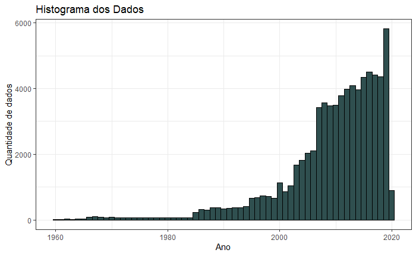

##### Desempenho dos clubes do Rio de Janeiro.

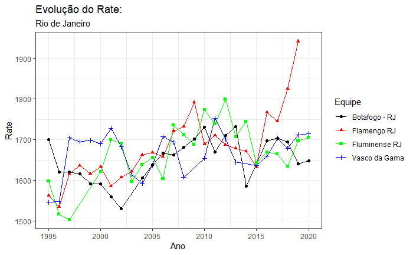

##### Desempenho dos clubes de São Paulo.

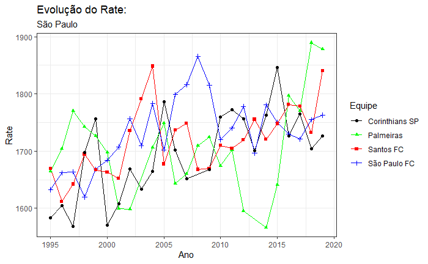

##### Desempenho Clube dos 13.

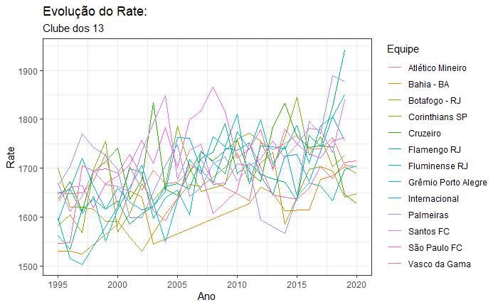

##### Mais meses na liderança do ranking brasileiro.

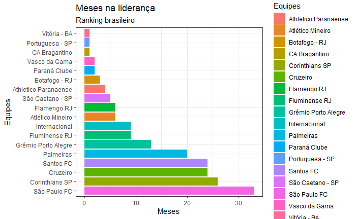

##### Aproveitamento dos mandantes pela federação.

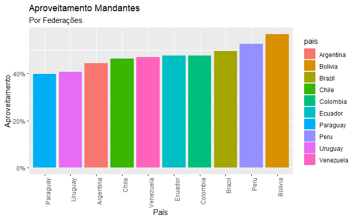

##### Tabela de Aproveitamento mandante, empate e visitante pelas fedarações.

|  | X | Brazil | Argentina | Chile | Bolivia | Colombia | Ecuador | Paraguay | Peru | Uruguay | Venezuela |
| --- | --- | --- | --- | --- | --- | --- | --- | --- | --- | --- | --- |
| 1 | Mandante | 49.57 | 44.47 | 46.35 | 56.7 | 47.78 | 47.69 | 39.89 | 52.6 | 40.66 | 47.03 |
| 2 | Empate | 25.85 | 28.84 | 24.63 | 21.35 | 29.05 | 25.85 | 26.37 | 25.97 | 24.58 | 28.13 |
| 3 | Visitante | 24.58 | 26.69 | 29.02 | 21.95 | 23.17 | 26.46 | 33.74 | 21.43 | 34.76 | 24.84 |

##### Aproveitamento em porcentagem de cada federação pela Copa Libertadores

Para calcular este aproveitamento não foram considerados os empates. O aproveitamento está linha x coluna. Exemplo: Na linha 1 com coluna 2 está representando aproveitamento dos clubes brasileiros contra os clubes argentinos pela Copa Libertadores. Os brasileiros ganharam 50,28% dos jogos contra os argentinos, excluindo os empates.

|  | X | Brazil | Argentina | Chile | Bolivia | Colombia | Ecuador | Paraguay | Peru | Uruguay | Venezuela |
| --- | --- | --- | --- | --- | --- | --- | --- | --- | --- | --- | --- |
| 1 | Brazil |  | 50.28 | 65 | 72.63 | 66.67 | 66.33 | 67.11 | 79.59 | 67.18 | 91.55 |
| 2 | Argentina | 49.72 |  | 68.6 | 69.88 | 64.93 | 66.34 | 57.5 | 70.94 | 62.5 | 82.09 |
| 3 | Chile | 35 | 31.4 |  | 64.44 | 46.05 | 59.72 | 39.37 | 64.38 | 45.45 | 77.55 |
| 4 | Bolivia | 27.37 | 30.12 | 35.56 |  | 36.84 | 42.86 | 29.33 | 32.26 | 35.29 | 82.35 |
| 5 | Colombia | 33.33 | 35.07 | 53.95 | 63.16 |  | 61.67 | 48.62 | 67.16 | 49.41 | 78.79 |
| 6 | Ecuador | 33.67 | 33.66 | 40.28 | 57.14 | 38.33 |  | 47.13 | 56.86 | 29.81 | 52.63 |
| 7 | Paraguay | 32.89 | 42.5 | 60.63 | 70.67 | 51.38 | 52.87 |  | 65.43 | 44.76 | 75.41 |
| 8 | Peru | 20.41 | 29.06 | 35.62 | 67.74 | 32.84 | 43.14 | 34.57 |  | 34.25 | 54.05 |
| 9 | Uruguay | 32.82 | 37.5 | 54.55 | 64.71 | 50.59 | 70.19 | 55.24 | 65.75 |  | 81.4 |
| 10 | Venezuela | 8.45 | 17.91 | 22.45 | 17.65 | 21.21 | 47.37 | 24.59 | 45.95 | 18.6 |  |

##### Os dez placares que mais se repetiram considerando todos os jogos e campeonatos.

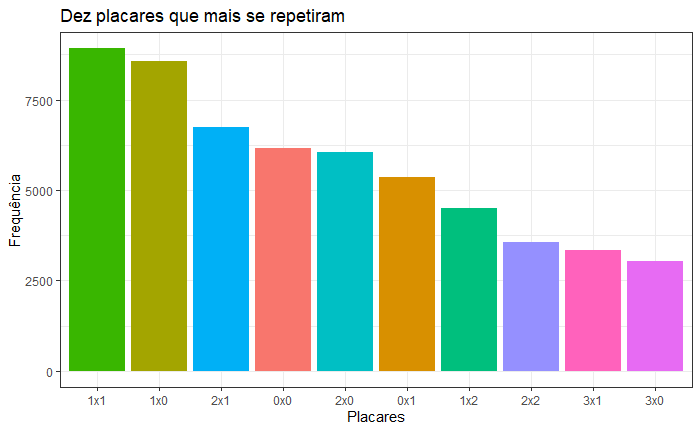

##### Média de gols por jogo a cada ano, e linha de tendência.

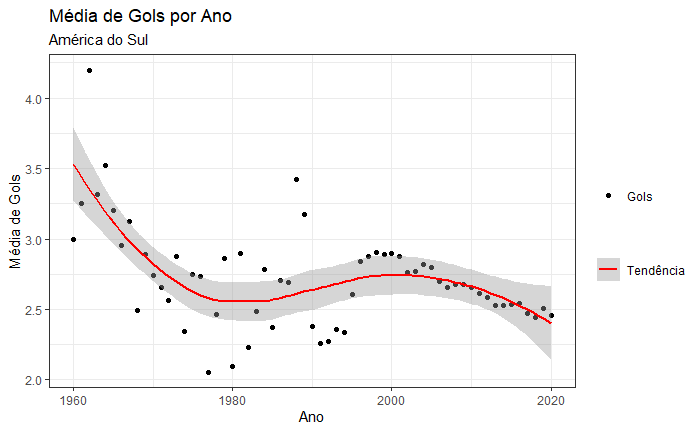

Com o modelo e a análise realizada sobre os dados podemos ter uma ótima refêrencia sobre o desempenho dos clubes e ainda matar alguamas curiosidades. Como foi o desempenho do seu time do coração ?